# SIBER Analysis of Coral Physiology

Peter Flood and Serena Hackerott

2/8/2024

# Setup

### Load Packages

```r
library(lme4) #required for mixed effects models
```

# Sample Data and Metadata

### Load and Organize Data

```r
##Load Data
#Note: Physiological metrics calculated in 02_PhysiologyMetrics.R file
Phys<-read.csv("Outputs/CoralData.csv", header=TRUE)

##Set factor variables
Phys$TimeP<-factor(Phys$TimeP, levels=c("TP1", "TP2", "TP3", "TP4"))
Phys$Site<-factor(Phys$Site, levels=c("KL", "SS"))
Phys$Genotype<-factor(Phys$Genotype, levels=c("AC8", "AC10", "AC12"))
Phys$Orig<-factor(Phys$Orig, levels=c("N", "T"))
Phys$Origin<-factor(Phys$Origin, levels=c("Native", "Transplant"))
Phys$Site.Orig<-factor(Phys$Site.Orig, levels=c("KL.N", "KL.T", "SS.N", "SS.T"))

##Set rownames
rownames(Phys)<-Phys$ID
```

### Check Correlation

```r
##Remove NA's
names(Phys)
```

```
 [1] "ID"              "RandN"           "TimeP"           "Site"            "Genotype"
 [6] "Orig"            "Origin"          "Set"             "Site.Orig"       "SA_cm2"
[11] "TP_ug.cm2_C"     "TP_ug.cm2_S"     "AFDW_mg.cm2_C"   "AFDW_mg.cm2_S"   "AFDW_mg.cm2_S.C"
[16] "Chl_ug.cm2"
```

```r
Phys.rm<-na.omit(Phys)

##Log +1 transform
Phys.log<-Phys.rm
Phys.log[,-c(1:10)]<-log(Phys.rm[,-c(1:10)]+1)

Phys.corr<-rcorr(as.matrix(Phys.log[,-c(1:10)]), type="pearson")
Phys.corr
```

```
                TP_ug.cm2_C TP_ug.cm2_S AFDW_mg.cm2_C AFDW_mg.cm2_S AFDW_mg.cm2_S.C
TP_ug.cm2_C            1.00        0.56          0.55          0.48            0.03
TP_ug.cm2_S            0.56        1.00          0.37          0.41            0.08
AFDW_mg.cm2_C          0.55        0.37          1.00          0.37           -0.49
AFDW_mg.cm2_S          0.48        0.41          0.37          1.00            0.60
AFDW_mg.cm2_S.C        0.03        0.08         -0.49          0.60            1.00
Chl_ug.cm2             0.37        0.16          0.33          0.50            0.20
                Chl_ug.cm2
TP_ug.cm2_C           0.37
TP_ug.cm2_S           0.16
AFDW_mg.cm2_C         0.33
AFDW_mg.cm2_S         0.50
AFDW_mg.cm2_S.C       0.20
Chl_ug.cm2            1.00

n= 190


P
                TP_ug.cm2_C TP_ug.cm2_S AFDW_mg.cm2_C AFDW_mg.cm2_S AFDW_mg.cm2_S.C
TP_ug.cm2_C                 0.0000      0.0000        0.0000        0.6401
TP_ug.cm2_S     0.0000                  0.0000        0.0000        0.2762
AFDW_mg.cm2_C   0.0000      0.0000                    0.0000        0.0000
AFDW_mg.cm2_S   0.0000      0.0000      0.0000                      0.0000
AFDW_mg.cm2_S.C 0.6401      0.2762      0.0000        0.0000
Chl_ug.cm2      0.0000      0.0248      0.0000        0.0000        0.0049
                Chl_ug.cm2
TP_ug.cm2_C     0.0000
TP_ug.cm2_S     0.0248
AFDW_mg.cm2_C   0.0000
AFDW_mg.cm2_S   0.0000
AFDW_mg.cm2_S.C 0.0049
Chl_ug.cm2
```

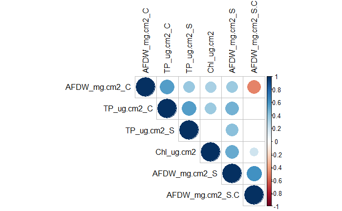

```r
diag(Phys.corr$P)<-0

corrplot(Phys.corr$r, type="upper", order="hclust", p.mat = Phys.corr$P, sig.level = 0.01, insig = "blank", tl.col="black")
```

Physiological variables of interest: Protein (Coral and Symbiont), Biomass (Coral and Symbiont), and Chlorophyll.

# SIBER Ellipses

## Prepare Input Data

### NMDS Ordination

SIBER runs on a two dimensional data set. So first, we need to reduce the dimensionality of the physiology data. We’re going to do this via Non-Metric Multidimensional Scaling (NMDS) on log+1 transformed physiological metrics of interest.

```r
#Select only the physiology columns of interest (without covariates) to put into the NMDS
names(Phys.log)
```

```
 [1] "ID"              "RandN"           "TimeP"           "Site"            "Genotype"
 [6] "Orig"            "Origin"          "Set"             "Site.Orig"       "SA_cm2"
[11] "TP_ug.cm2_C"     "TP_ug.cm2_S"     "AFDW_mg.cm2_C"   "AFDW_mg.cm2_S"   "AFDW_mg.cm2_S.C"
[16] "Chl_ug.cm2"
```

```r
phys.log.num <- Phys.log[,c(11:14, 16)]

#Run NMDS
phys.nmds <- metaMDS(phys.log.num, distance = "euclidean", k = 2, autotransform = F)
```

```
Run 15Run 16 stress 0.1028877
*** Best solution repeated 3 times
```

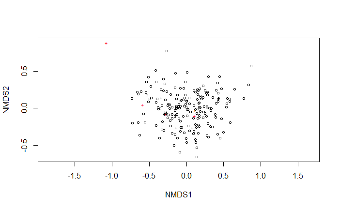

```r
#Quick plot of NMDS output
ordiplot(phys.nmds)
```

### NMDS Model

```r
##Correlation with Physiology Metrics
phys.envi.fit <- envfit(phys.nmds, phys.log.num)
phys.envi.fit
```

```
***VECTORS

                 NMDS1    NMDS2     r2 Pr(>r)
TP_ug.cm2_C   -0.88063 -0.47381 0.6916  0.001 ***
TP_ug.cm2_S   -0.60040 -0.79970 0.8853  0.001 ***
AFDW_mg.cm2_C -0.95472 -0.29751 0.3476  0.001 ***
AFDW_mg.cm2_S -0.99909  0.04255 0.4503  0.001 ***
Chl_ug.cm2    -0.69868  0.71543 0.9756  0.001 ***
---
Signif. codes:  0 ‘***’ 0.001 ‘**’ 0.01 ‘*’ 0.05 ‘.’ 0.1 ‘ ’ 1
Permutation: free
Number of permutations: 999
```

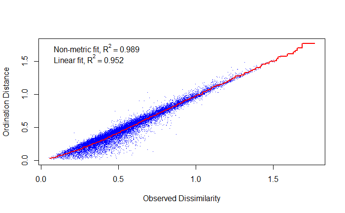

```r
phys.envi.vectors <- phys.envi.fit[["vectors"]][["arrows"]]

##Check Stress
stressplot(phys.nmds)
```

```r
NMDS.stress<- sprintf("Stress = %.2f", phys.nmds$stress)
NMDS.stress
```

```
[1] "Stress = 0.10"
```

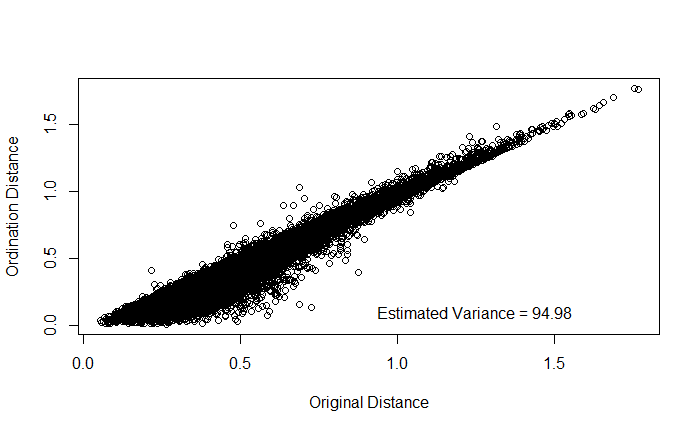

```r
#Calculate Estimated Variance Explained per Axis
# Not a true % variance explained, but an estimate from
# correlating the original distance matrix with the ordination distance
phys.ord.dist <- vegdist(phys.nmds$points[,1:2], method = "euclidean")
phys.distance<-vegdist(phys.log.num, method="euclidean")
plot(phys.distance,phys.ord.dist, xlab = "Original Distance", ylab = "Ordination Distance")
phys.dist.cor<-cor(phys.distance,phys.ord.dist)^2
phys.var.label<-sprintf("Estimated Variance = %.2f", phys.dist.cor*100)
text(1.25, 0.1, phys.var.label)
```

```r
#Estimate % Variance on Axis 1
phys.ax1_dist<-vegdist(phys.nmds$points[,1],method="euclidean")
NMDS1<-sprintf("%1.2f",(cor(phys.distance,phys.ax1_dist)^2)*100)
NMDS1
```

```
[1] "66.42"
```

```r
#Estimate % Variance on Axis 2
phys.ax2_dist<-vegdist(phys.nmds$points[,2],method="euclidean")
NMDS2<-sprintf("%1.2f",(cor(phys.distance,phys.ax2_dist)^2)*100)
NMDS2
```

```
[1] "27.47"
```

```r
#Prepare for Plotting
phys.nmds.samples.plot.data <- cbind(phys.log.num, phys.nmds$points)
phys.nmds.samples.plot.data$ID<-rownames(phys.nmds.samples.plot.data)
phys.nmds.samples.plot.data<-merge(phys.nmds.samples.plot.data, Phys.rm[,c(1,3:9)])
phys.nmds.samples.plot.data$Geno.Orig<-paste(phys.nmds.samples.plot.data$Genotype, phys.nmds.samples.plot.data$Orig, sep=".")
phys.nmds.samples.plot.data$Geno.Orig<-factor(phys.nmds.samples.plot.data$Geno.Orig, levels=c("AC8.N","AC8.T", "AC10.N", "AC10.T", "AC12.N", "AC12.T"), ordered=TRUE)

phys.nmds.covariates.plot.data <- data.frame(phys.envi.vectors)
phys.nmds.covariates.plot.data$Covariate<-c(rownames(phys.envi.vectors))
names(phys.nmds.covariates.plot.data)[1:2]<-c("MDS1", "MDS2")
phys.nmds.covariates.plot.data$Covariate
```

```
[1] "TP_ug.cm2_C"   "TP_ug.cm2_S"   "AFDW_mg.cm2_C" "AFDW_mg.cm2_S" "Chl_ug.cm2"
```

```r
phys.nmds.covariates.plot.data$Metric<-c("Protein_C", "Protein_S", "Biomass_C", "Biomass_S", "Chlorophyll")
```

### Plot NMDS

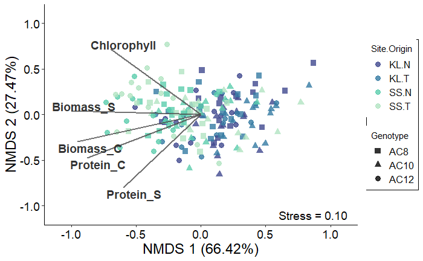

```r
phys.nmds.plot<-ggplot(data = phys.nmds.samples.plot.data, aes(x = MDS1, y = MDS2)) +
  geom_point(data = phys.nmds.samples.plot.data, aes(colour = Site.Orig, shape=Genotype), size = point.sz-1, alpha = 0.8) +
  scale_colour_manual(values =Orig.colors.o)+
  scale_shape_manual(values=Geno.shapes.o)+
  theme_classic()+
  scale_x_continuous(limits = c(-1.1, 1.1))+
  scale_y_continuous(limits = c(-1.1, 1.1))+
   theme(axis.title.x = element_text(size = axis.title.sz),
        axis.title.y = element_text(size = axis.title.sz),
        axis.text.x=element_text(size=axis.txt.sz, colour="black"),
        axis.text.y=element_text(size=axis.txt.sz, colour="black"),
        legend.text=element_text(size=leg.txt.sz),
        legend.box.background = element_rect(color = "black"))+
  geom_segment(aes(x = 0, y = 0, xend = MDS1, yend = MDS2),
               data = phys.nmds.covariates.plot.data, linewidth =bar.sz, alpha = 0.8, colour = "grey30") +
  geom_text(data=phys.nmds.covariates.plot.data, aes(x=MDS1, y=MDS2, label=Metric, fontface = "bold", hjust=0.15*(1-sign(MDS1)),vjust=0.6*(1-sign(MDS2))), colour = "grey20", size=sig.sz)+
  labs(x=paste0('NMDS 1 (',NMDS1,"%)"), y=paste0('NMDS 2 (',NMDS2,"%)"), color="Site.Origin")+
  annotate("text", x = .6, y = -1.1, label = NMDS.stress, hjust=0, size=sig.sz); phys.nmds.plot
```

### Data Prep for SIBER

```r
#Prepare data to be input into SIBER
phys.siber.input <- phys.nmds$points %>% #extract 2-D physiology axes from NMDS
  bind_cols(#add back covariates from original phys data
    select(Phys.log, ID:Site.Orig) #select those covariate columns
  ) %>%
  #SIBER object needs four specific columns
  #iso1, iso2, group, and community
  #Need to manipulate the data to match that format
  #create  group variable that combines site, genotype and origin
  unite("group", c(Site, Genotype, Orig), sep = "_") %>%
  #rename variables to match names for SIBER
  dplyr::rename(community = TimeP, iso1 = MDS1, iso2 = MDS2) %>%
  #retain only columns for SIBER
  select(iso1, iso2, group, community)
```

## Run SIBER

Grouping by each genotype at each site, timepoint, and from each origin

```r
# create SIBER object
phys.siber.object <- createSiberObject(phys.siber.input)

# sample sizes by group
phys.siber.object[["sample.sizes"]]

# Calculate sumamry statistics for each group: TA, SEA and SEAc
group.ML <- groupMetricsML(phys.siber.object)
print(group.ML)

##Save SIBER Object in Outputs
save(phys.siber.object, file="Outputs/SIBER/Phys.SIBER.Object.RData")
```

[output not shown]

### Visualize SIBER Ellipses

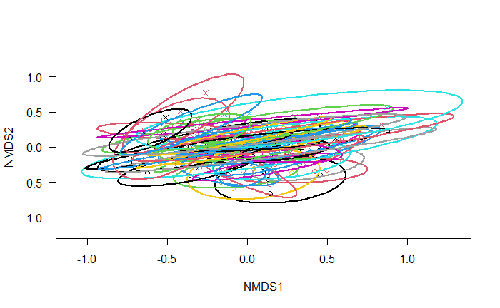

```r
##Load SIBER Object
load("Outputs/SIBER/Phys.SIBER.Object.RData")


#Create lists of plotting arguments for ellipses
group.ellipses.args  <- list(n = 100, p.interval = 0.95, lty = 1, lwd = 2)

#Plot SIBER groups
plotSiberObject(phys.siber.object,
                  ax.pad = 2,
                  hulls = F, community.hulls.args,
                  ellipses = T, group.ellipses.args,
                  group.hulls = F, group.hull.args,
                  bty = "L",
                  iso.order = c(1,2),
                  xlab = "NMDS1", x.limits=c(-1.1, 1.3),
                  ylab = "NMDS2", y.limits=c(-1.2, 1.2))
```

```r
NA
NA
```

## Ellipses Across Time and Space

Plotting 95% confidence intervals of the physiological niche space for each group.

## By Origin

### KL

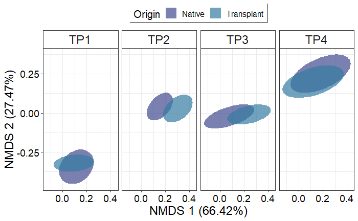

```r
ellipses.origin.plot_KL<-ggplot(data = phys.nmds.samples.plot.data[which(phys.nmds.samples.plot.data$Site=="KL"),], aes(x = MDS1, y = MDS2)) +
  stat_conf_ellipse(data = phys.nmds.samples.plot.data[which(phys.nmds.samples.plot.data$Site=="KL"),], geom = "polygon", level = 0.95, alpha = 0.7, aes(fill= Origin))+
  scale_fill_manual(values =Orig.colors.o[1:2])+
  theme_bw()+
   theme(axis.title.x = element_text(size = axis.title.sz),
        axis.title.y = element_text(size = axis.title.sz),
        axis.text.x=element_text(size=axis.txt.sz, colour="black"),
        axis.text.y=element_text(size=axis.txt.sz, colour="black"),
        legend.title=element_text(size=leg.title.sz),
        legend.text=element_text(size=leg.txt.sz),
        legend.box.background = element_rect(color = "black"),
        legend.position="top",
        strip.text = element_text(size=axis.title.sz),
        strip.background=element_rect(fill="white"))+
  labs(x=paste0('NMDS 1 (',NMDS1,"%)"), y=paste0('NMDS 2 (',NMDS2,"%)"))+
  facet_wrap(~TimeP, nrow=1); ellipses.origin.plot_KL
```

### SS

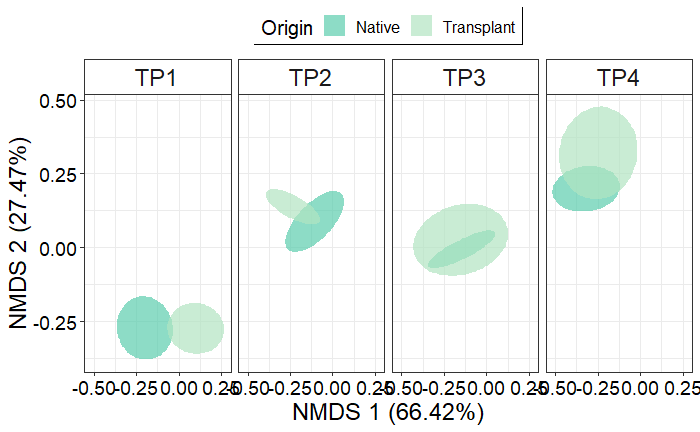

```r
ellipses.origin.plot_SS<-ggplot(data = phys.nmds.samples.plot.data[which(phys.nmds.samples.plot.data$Site=="SS"),], aes(x = MDS1, y = MDS2)) +
  stat_conf_ellipse(data = phys.nmds.samples.plot.data[which(phys.nmds.samples.plot.data$Site=="SS"),], geom = "polygon", level = 0.95, alpha = 0.7, aes(fill= Origin))+
  scale_fill_manual(values =Orig.colors.o[3:4])+
  theme_bw()+
   theme(axis.title.x = element_text(size = axis.title.sz),
        axis.title.y = element_text(size = axis.title.sz),
        axis.text.x=element_text(size=axis.txt.sz, colour="black"),
        axis.text.y=element_text(size=axis.txt.sz, colour="black"),
        legend.title=element_text(size=leg.title.sz),
        legend.text=element_text(size=leg.txt.sz),
        legend.box.background = element_rect(color = "black"),
        legend.position="top",
        strip.text = element_text(size=axis.title.sz),
        strip.background=element_rect(fill="white"))+
  labs(x=paste0('NMDS 1 (',NMDS1,"%)"), y=paste0('NMDS 2 (',NMDS2,"%)"))+
  facet_wrap(~TimeP, nrow=1); ellipses.origin.plot_SS
```

## By Origin and Genotype

Need to decide the best way to display these.

### KL

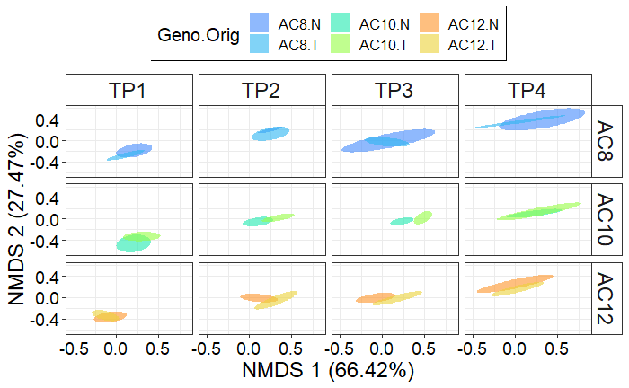

```r
ellipses.orig.geno.grid_KL<-ggplot(data = phys.nmds.samples.plot.data[which(phys.nmds.samples.plot.data$Site=="KL"),], aes(x = MDS1, y = MDS2)) +
  stat_conf_ellipse(data = phys.nmds.samples.plot.data[which(phys.nmds.samples.plot.data$Site=="KL"),], geom = "polygon", level = 0.95, aes(fill=Geno.Orig), alpha=0.6)+
  scale_fill_manual(values =Geno.Orig.colors.o)+
  theme_bw()+
   theme(axis.title.x = element_text(size = axis.title.sz),
        axis.title.y = element_text(size = axis.title.sz),
        axis.text.x=element_text(size=axis.txt.sz, colour="black"),
        axis.text.y=element_text(size=axis.txt.sz, colour="black"),
        legend.title=element_text(size=leg.title.sz),
        legend.text=element_text(size=leg.txt.sz),
        legend.box.background = element_rect(color = "black"),
        legend.position="top",
        strip.text = element_text(size=axis.title.sz),
        strip.background=element_rect(fill="white"))+
  labs(x=paste0('NMDS 1 (',NMDS1,"%)"), y=paste0('NMDS 2 (',NMDS2,"%)"))+
  facet_grid(Genotype~TimeP); ellipses.orig.geno.grid_KL
```

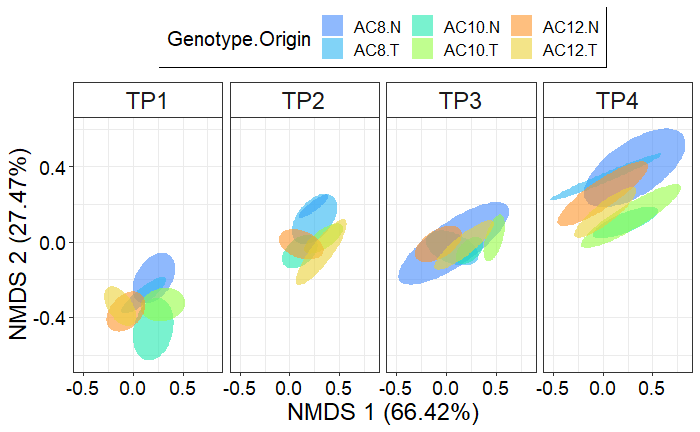

```r
ellipses.orig.geno.plot_KL.a<-ggplot(data = phys.nmds.samples.plot.data[which(phys.nmds.samples.plot.data$Site=="KL"),], aes(x = MDS1, y = MDS2)) +
  stat_conf_ellipse(data = phys.nmds.samples.plot.data[which(phys.nmds.samples.plot.data$Site=="KL"),], geom = "polygon", level = 0.95,  aes(fill=Geno.Orig), alpha=0.6)+
  scale_fill_manual(values =Geno.Orig.colors.o)+
  theme_bw()+
   theme(axis.title.x = element_text(size = axis.title.sz),
        axis.title.y = element_text(size = axis.title.sz),
        axis.text.x=element_text(size=axis.txt.sz, colour="black"),
        axis.text.y=element_text(size=axis.txt.sz, colour="black"),
        legend.title=element_text(size=leg.title.sz),
        legend.text=element_text(size=leg.txt.sz),
        legend.box.background = element_rect(color = "black"),
        legend.position="top",
        strip.text = element_text(size=axis.title.sz),
        strip.background=element_rect(fill="white"))+
  labs(x=paste0('NMDS 1 (',NMDS1,"%)"), y=paste0('NMDS 2 (',NMDS2,"%)"), fill="Genotype.Origin")+
  facet_wrap(~TimeP, nrow=1); ellipses.orig.geno.plot_KL.a
```

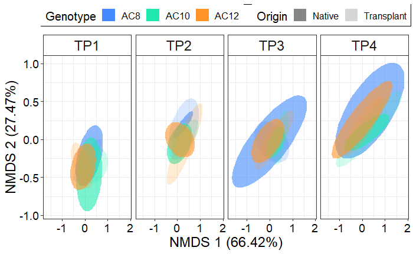

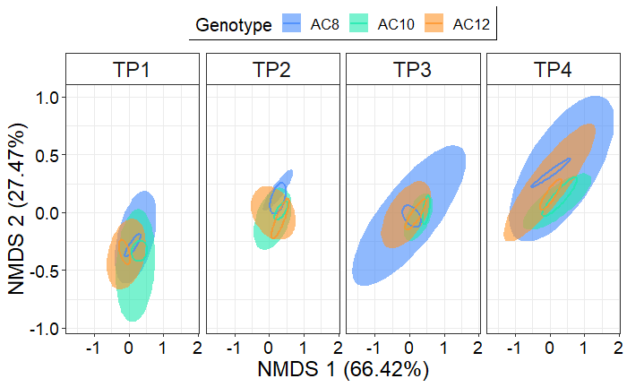

### SS

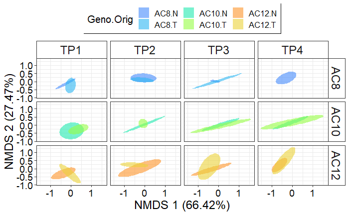

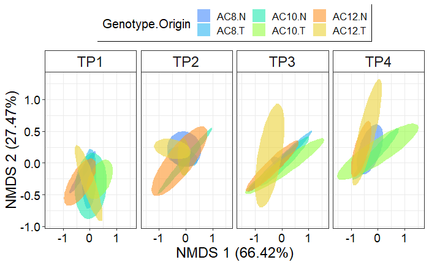

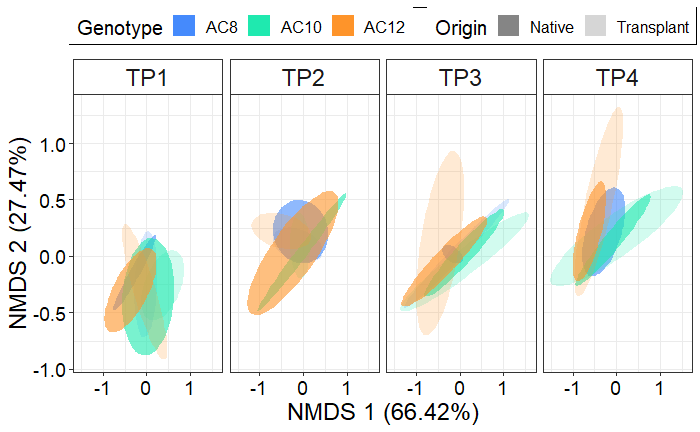

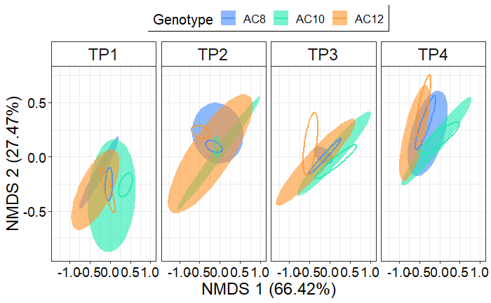

# Ellipse Overlap

## Calculate Percent Overlap

Calculating the overlap of physiological niche space between corals of the same genotype, at the same site and timepoint. Using Percent of Niche Overlap as a more informative indicator of how similar the Transplant corals are to their Native clonemates.

First, calculating the area of the 95% prediction ellipses for each group as well as the maximum likelihood of overlap between physiological niche ellipses.

### Calculate Niche Areas

```r
Niches<-data.frame(rbind(
  #KL AC10
  maxLikOverlap("TP1.KL_AC10_N", "TP1.KL_AC10_T", phys.siber.object, p = 0.95, n = 360),
  maxLikOverlap("TP2.KL_AC10_N", "TP2.KL_AC10_T", phys.siber.object, p = 0.95, n = 360),
  maxLikOverlap("TP3.KL_AC10_N", "TP3.KL_AC10_T", phys.siber.object, p = 0.95, n = 360),
  maxLikOverlap("TP4.KL_AC10_N", "TP4.KL_AC10_T", phys.siber.object, p = 0.95, n = 360),
  #KL AC12
  maxLikOverlap("TP1.KL_AC12_N", "TP1.KL_AC12_T", phys.siber.object, p = 0.95, n = 360),
  maxLikOverlap("TP2.KL_AC12_N", "TP2.KL_AC12_T", phys.siber.object, p = 0.95, n = 360),
  maxLikOverlap("TP3.KL_AC12_N", "TP3.KL_AC12_T", phys.siber.object, p = 0.95, n = 360),
  maxLikOverlap("TP4.KL_AC12_N", "TP4.KL_AC12_T", phys.siber.object, p = 0.95, n = 360),
  #KL AC8
  maxLikOverlap("TP1.KL_AC8_N", "TP1.KL_AC8_T", phys.siber.object, p = 0.95, n = 360),
  maxLikOverlap("TP2.KL_AC8_N", "TP2.KL_AC8_T", phys.siber.object, p = 0.95, n = 360),
  maxLikOverlap("TP3.KL_AC8_N", "TP3.KL_AC8_T", phys.siber.object, p = 0.95, n = 360),
  maxLikOverlap("TP4.KL_AC8_N", "TP4.KL_AC8_T", phys.siber.object, p = 0.95, n = 360),
  #SS AC10
  maxLikOverlap("TP1.SS_AC10_N", "TP1.SS_AC10_T", phys.siber.object, p = 0.95, n = 360),
  maxLikOverlap("TP2.SS_AC10_N", "TP2.SS_AC10_T", phys.siber.object, p = 0.95, n = 360),
  maxLikOverlap("TP3.SS_AC10_N", "TP3.SS_AC10_T", phys.siber.object, p = 0.95, n = 360),
  maxLikOverlap("TP4.SS_AC10_N", "TP4.SS_AC10_T", phys.siber.object, p = 0.95, n = 360),
  #SS AC12
  maxLikOverlap("TP1.SS_AC12_N", "TP1.SS_AC12_T", phys.siber.object, p = 0.95, n = 360),
  maxLikOverlap("TP2.SS_AC12_N", "TP2.SS_AC12_T", phys.siber.object, p = 0.95, n = 360),
  maxLikOverlap("TP3.SS_AC12_N", "TP3.SS_AC12_T", phys.siber.object, p = 0.95, n = 360),
  maxLikOverlap("TP4.SS_AC12_N", "TP4.SS_AC12_T", phys.siber.object, p = 0.95, n = 360),
  #SS AC8
  maxLikOverlap("TP1.SS_AC8_N", "TP1.SS_AC8_T", phys.siber.object, p = 0.95, n = 360),
  maxLikOverlap("TP2.SS_AC8_N", "TP2.SS_AC8_T", phys.siber.object, p = 0.95, n = 360),
  maxLikOverlap("TP3.SS_AC8_N", "TP3.SS_AC8_T", phys.siber.object, p = 0.95, n = 360),
  maxLikOverlap("TP4.SS_AC8_N", "TP4.SS_AC8_T", phys.siber.object, p = 0.95, n = 360)
  ))

names(Niches)<-c("Native", "Transplant", "Overlap")
Niches$Site<-c(rep("KL", 12), rep("SS", 12))
Niches$Genotype<-c(rep(c(rep("AC10",4), rep("AC12",4), rep("AC8",4)),2))
Niches$TimeP<-rep(c("TP1", "TP2", "TP3", "TP4"),6)
```

### Calculate Overlap

Proportion of niche overlap = Area of overlap between Native and Transplant physiological niches / Area of the Native niche

Using Native niche area as the denominator which may be more informative as the baseline niche space

```r
##Proportion of Native Niche Area
Niches$pOverlap<-Niches$Overlap/Niches$Native

##Write out dataframe
write.csv(Niches, "Outputs/SIBER_p.Overlap.csv", row.names=FALSE)

##Read in
Niches<-read.csv("Outputs/SIBER_p.Overlap.csv", header=TRUE)

##Set factor variables
Niches$Site<-factor(Niches$Site, levels=c("KL", "SS"))
Niches$Genotype<-factor(Niches$Genotype, levels=c("AC8", "AC10", "AC12"))
Niches$TimeP<-factor(Niches$TimeP)
```

## Visualize Overlap over Time

### By Genotype

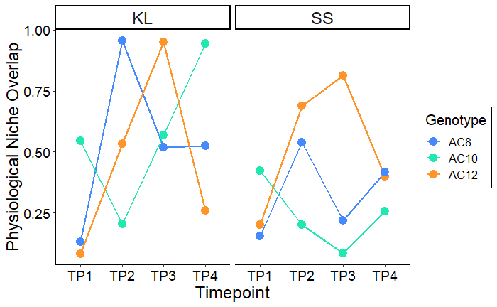

```r
##Plot Niche Overlap across Timepoints
Overlap.plot<-ggplot(Niches, aes(x=TimeP, y=pOverlap, colour=Genotype, group=Genotype)) +
  geom_line(linewidth=bar.sz)+
  geom_point(size=point.sz)+
  scale_colour_manual(values =Geno.colors.o)+
  theme_classic()+
  theme(axis.title.x = element_text(size = axis.title.sz),
        axis.title.y = element_text(size = axis.title.sz),
        axis.text.x=element_text(size=axis.txt.sz, colour="black"),
        axis.text.y=element_text(size=axis.txt.sz, colour="black"),
        legend.text=element_text(size=leg.txt.sz),
        legend.title=element_text(size=leg.title.sz),
        legend.box.background = element_rect(color = "black"),
        strip.text=element_text(size=axis.title.sz))+
  labs(x="Timepoint", y="Physiological Niche Overlap")+
  facet_wrap(~Site); Overlap.plot

##Save Figure
ggsave(filename="Figures/04_SIBER/NicheOverlap.png", plot=Overlap.plot, dpi=300, width=8, height=5, units="in")
```

#### KL

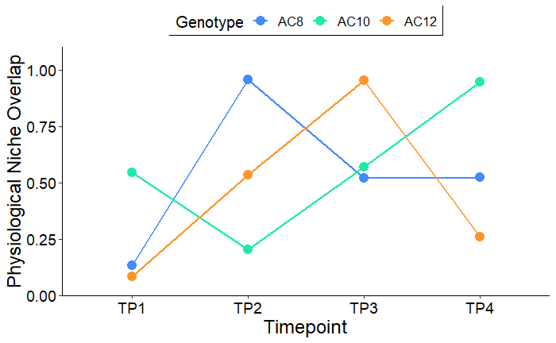

```r
##Plot Niche Overlap across Timepoints
Overlap_KL.plot<-ggplot(Niches[which(Niches$Site=="KL"),], aes(x=TimeP, y=pOverlap, colour=Genotype, group=Genotype)) +
  geom_line(linewidth=bar.sz)+
  geom_point(size=point.sz)+
  scale_colour_manual(values =Geno.colors.o)+
  theme_classic()+
  theme(axis.title.x = element_text(size = axis.title.sz),
        axis.title.y = element_text(size = axis.title.sz),
        axis.text.x=element_text(size=axis.txt.sz, colour="black"),
        axis.text.y=element_text(size=axis.txt.sz, colour="black"),
        legend.text=element_text(size=leg.txt.sz),
        legend.title=element_text(size=leg.title.sz),
        legend.box.background = element_rect(color = "black"),
        legend.position="top")+
  labs(x="Timepoint", y="Physiological Niche Overlap")+
  ylim(0.05,1.05); Overlap_KL.plot
```

#### SS

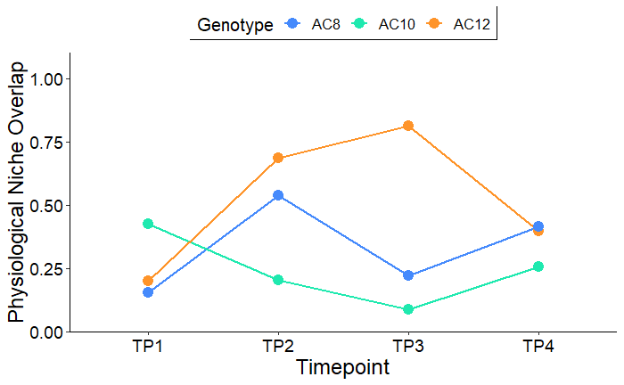

```r
##Plot Niche Overlap across Timepoints
Overlap_SS.plot<-ggplot(Niches[which(Niches$Site=="SS"),], aes(x=TimeP, y=pOverlap, colour=Genotype, group=Genotype)) +
  geom_line(linewidth=bar.sz)+
  geom_point(size=point.sz)+
  scale_colour_manual(values =Geno.colors.o)+
  theme_classic()+
  theme(axis.title.x = element_text(size = axis.title.sz),
        axis.title.y = element_text(size = axis.title.sz),
        axis.text.x=element_text(size=axis.txt.sz, colour="black"),
        axis.text.y=element_text(size=axis.txt.sz, colour="black"),
        legend.text=element_text(size=leg.txt.sz),
        legend.title=element_text(size=leg.title.sz),
        legend.box.background = element_rect(color = "black"),
        legend.position="top")+
  labs(x="Timepoint", y="Physiological Niche Overlap")+
  ylim(0.05,1.05); Overlap_SS.plot
```

### Across Genotypes

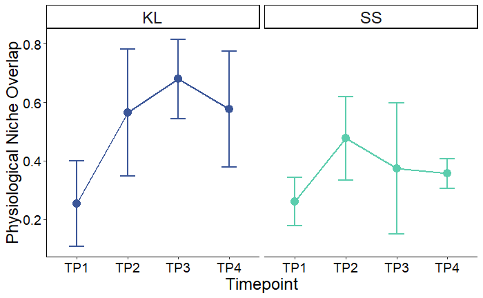

```r
##Summary statistics by Site and Origin
pOverlap.sum<-summarySE(Niches, measurevar="pOverlap", groupvars=c("Site", "TimeP"), na.rm=TRUE)

##Plot Average Niche Overlap across Timepoints
Overlap_Avg.plot<-ggplot(pOverlap.sum, aes(x=TimeP, y=pOverlap, colour=Site, group=1)) +
  scale_colour_manual(values=Site.colors.o)+
  geom_errorbar(aes(ymin=pOverlap-se, ymax=pOverlap+se), width=cap.sz, linewidth=bar.sz) +
  geom_line(linewidth=bar.sz)+
  geom_point(size=point.sz)+
  theme_classic()+
  theme(axis.title.x = element_text(size = axis.title.sz),
        axis.title.y = element_text(size = axis.title.sz),
        axis.text.x=element_text(size=axis.txt.sz, colour="black"),
        axis.text.y=element_text(size=axis.txt.sz, colour="black"),
        legend.position="none",
        strip.text=element_text(size=axis.title.sz))+
  labs(x="Timepoint", y="Physiological Niche Overlap")+
  facet_wrap(~Site); Overlap_Avg.plot

##Save Figure
ggsave(filename="Figures/04_SIBER/AvgNicheOverlap.png", plot=Overlap_Avg.plot, dpi=300, width=6, height=5, units="in")
```

#### KL

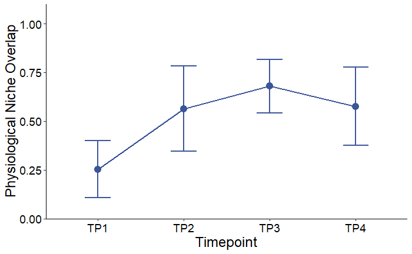

```r
##Plot Average Niche Overlap across Timepoints
Overlap_Avg_KL.plot<-ggplot(pOverlap.sum[which(pOverlap.sum$Site=="KL"),], aes(x=TimeP, y=pOverlap, colour=Site, group=1)) +
  scale_colour_manual(values=Site.colors.o[1])+
  geom_errorbar(aes(ymin=pOverlap-se, ymax=pOverlap+se), width=cap.sz, linewidth=bar.sz) +
  geom_line(linewidth=bar.sz)+
  geom_point(size=point.sz)+
  theme_classic()+
  theme(axis.title.x = element_text(size = axis.title.sz),
        axis.title.y = element_text(size = axis.title.sz),
        axis.text.x=element_text(size=axis.txt.sz, colour="black"),
        axis.text.y=element_text(size=axis.txt.sz, colour="black"),
        legend.position="none")+
  labs(x="Timepoint", y="Physiological Niche Overlap")+
  ylim(0.05,1.05); Overlap_Avg_KL.plot
```

#### SS

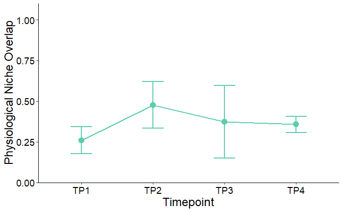

```r
##Plot Average Niche Overlap across Timepoints
Overlap_Avg_SS.plot<-ggplot(pOverlap.sum[which(pOverlap.sum$Site=="SS"),], aes(x=TimeP, y=pOverlap, colour=Site, group=1)) +
  scale_colour_manual(values=Site.colors.o[2])+
  geom_errorbar(aes(ymin=pOverlap-se, ymax=pOverlap+se), width=cap.sz, linewidth=bar.sz) +
  geom_line(linewidth=bar.sz)+
  geom_point(size=point.sz)+
  theme_classic()+
  theme(axis.title.x = element_text(size = axis.title.sz),
        axis.title.y = element_text(size = axis.title.sz),
        axis.text.x=element_text(size=axis.txt.sz, colour="black"),
        axis.text.y=element_text(size=axis.txt.sz, colour="black"),
        legend.position="none")+
  labs(x="Timepoint", y="Physiological Niche Overlap")+
  ylim(0.05,1.05); Overlap_Avg_SS.plot
```